# Quantile normalizing your own data to make it more comparable to refine.bio data

J. Taroni for CCDL

2019

## Background

Datasets that are downloaded from the web interface of refine.bio are [quantile normalized](https://en.wikipedia.org/wiki/Quantile_normalization) because we allow users to aggregate multiple platforms (e.g., microarray chips) and even multiple technologies. Quantile normalization (QN) ensures that the underlying distributions of samples are the same.

If you are interested in comparing your own data to data you have downloaded from the refine.bio website, you may wish to quantile normalize it using the reference distribution we’ve used in refine.bio.

You can read more about the reference distribution and how it is generated in the [quantile normalization section](http://docs.refine.bio/en/latest/main_text.html#quantile-normalization) of our [documentation](http://docs.refine.bio/en/latest/).

In this example, we’ll demonstrate how to obtain the reference distribution from the refine.bio API and apply it to your own data in R.

### Dataset

We used [`GSE39842`](https://www.ncbi.nlm.nih.gov/geo/query/acc.cgi?acc=GSE39842) in another module of the GitHub repository of examples: [`AlexsLemonade/refinebio-examples/compare-processing`](https://github.com/AlexsLemonade/refinebio-examples/tree/master/compare-processing).

The submitters used RMA to process their data. We have already converted the gene identifiers to Ensembl gene ids and can obtain the TSV file with these data from GitHub, placing it in the `data` directory we create below with `bash`.

```r
mkdir data
wget --directory-prefix=data https://github.com/AlexsLemonade/refinebio-examples/raw/c97cad6a8342d9bb54f120dbd7c7f12b03e3f799/compare-processing/data/GSE39842_RMA_converted.tsv # Replace with link to desired RMA converted file
```

## Obtaining a refine.bio QN target

We’ll use the terms “QN target” and “reference distribution” interchangeably to refer to the vector of values we use to quantile normalize `GSE39842`.

We can query the refine.bio API like so:

```
https://api.refine.bio/qn_targets/?organism=<SCIENTIFIC_NAME>
```

where we would replace `<SCIENTIFIC_NAME>` with the name of the species we are interested in.

We’d query the API for the zebrafish QN target like so:

```
https://api.refine.bio/qn_targets/?organism=DANIO_RERIO
```

Here, we’ll use the `jsonlite` R package to extract the information we need to obtain the TSV file with the zebrafish reference distribution values.

```r
if (!("jsonlite" %in% installed.packages())) {
  install.packages("jsonlite")
}

qn_target_info <- jsonlite::fromJSON("https://api.refine.bio/v1/qn_targets/danio_rerio")
```

We need the `s3_url`, which tells us the link where the file is available for download from. We can read this data into R with the URL directly later on in this notebook.

```r
qn_url <- qn_target_info$s3_url
```

This is all the information we need to continue.

```r
rm(qn_target_info)
```

## Set up

We need the [`preprocessCore`](https://bioconductor.org/packages/release/bioc/html/preprocessCore.html) package to perform quantile normalization.

```r
if (!("preprocessCore" %in% installed.packages())) {
  BiocManager::install("preprocessCore", update = FALSE)
}
```

```r
`%>%` <- dplyr::`%>%`
```

### Read in data

First, the gene expression matrix.

```r
expression_file <- file.path("data",
                             "GSE39842_RMA_converted.tsv" # Replace with name of desired expression file
                             )
expression_df <- readr::read_tsv(expression_file)
```

We need a matrix of our expression data to perform quantile normalization.

```r
expression_matrix <- expression_df %>%
  # filter out any of the control probes
  dplyr::filter(!grepl("AFFX", ENSEMBL)) %>%
  as.data.frame() %>%
  tibble::column_to_rownames("ENSEMBL") %>%
  as.matrix()
```

The QN target will ultimately need to be a vector:

```r
qn_target <- as.vector(as.matrix(readr::read_tsv(qn_url,
                                                 col_names = FALSE)))
```

## Quantile normalization

```r
qn_matrix <- preprocessCore::normalize.quantiles.use.target(expression_matrix,
                                                            qn_target)
```

To write this to file or to do plotting with `ggplot2`, we’ll want to neaten things a bit (e.g., use column names).

```r
colnames(qn_matrix) <- colnames(expression_df)[-1]
qn_df <- data.frame(Gene = rownames(expression_matrix),
                    qn_matrix)
```

Let’s write the quantile normalized data to file.

```r
qn_expression_file <- file.path("data",
                                "GSE39842_RMA_refinebio_QN.tsv" # Replace with relevant output quantile normalized file name
                                )
readr::write_tsv(qn_df, path = qn_expression_file)
```

### Plotting

Let’s make some density plots to demonstrate the effect of quantile normalization.

#### Before normalization

```r
# we need this information in long format to make the plots
exprs_long_df <- expression_df %>%
  reshape2::melt() %>%
  dplyr::mutate(Sample = variable) %>%
  dplyr::select(-variable)
```

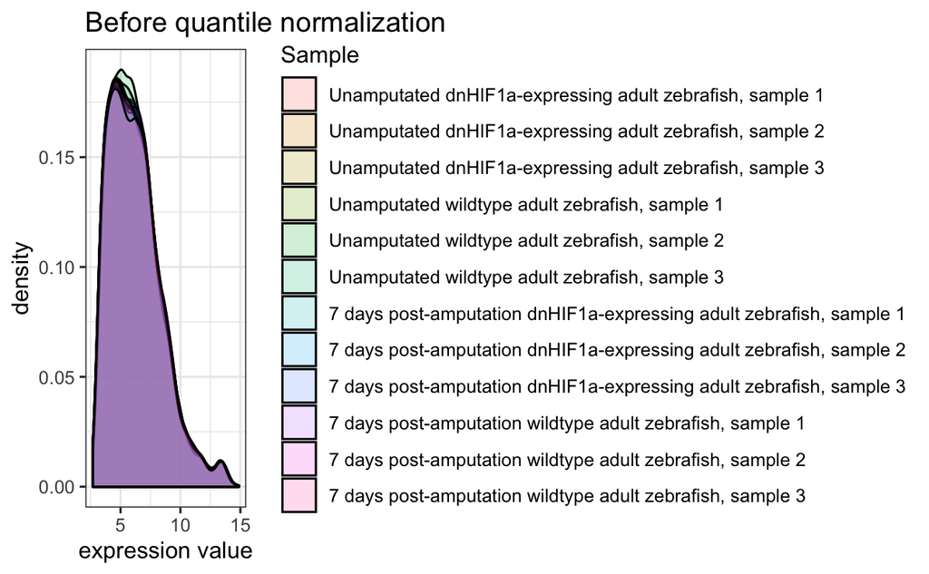

```r
exprs_long_df %>%
  ggplot2::ggplot(ggplot2::aes(x = value, fill = Sample)) +
  ggplot2::geom_density(alpha = 0.2) +
  ggplot2::theme_bw() +
  ggplot2::labs(title = "Before quantile normalization",
                x = "expression value")
```

The distributions look pretty similar, but they’re not the *same*.

#### After normalization

```r
qn_long_df <- qn_df %>%
  reshape2::melt() %>%
  # because the sample names were the column names, they are not pretty!
  dplyr::mutate(Sample = gsub("X7", "7",
                              gsub("[[:punct:]]", " ", variable))) %>%
  dplyr::select(-variable)
```

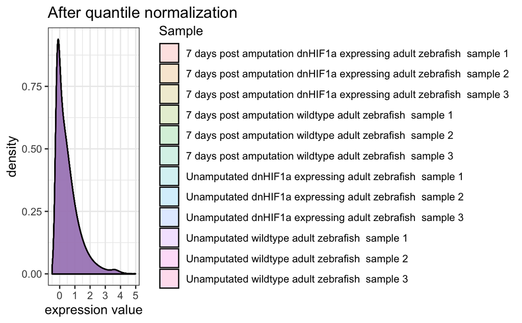

```r
qn_p <- qn_long_df %>%
  ggplot2::ggplot(ggplot2::aes(x = value, fill = Sample)) +
  ggplot2::geom_density(alpha = 0.2) +
  ggplot2::theme_bw() +
  ggplot2::labs(title = "After quantile normalization",
                x = "expression value")
qn_p
```

This looks like all the samples follow the same distribution. We can use `facet_wrap` to get a better look.

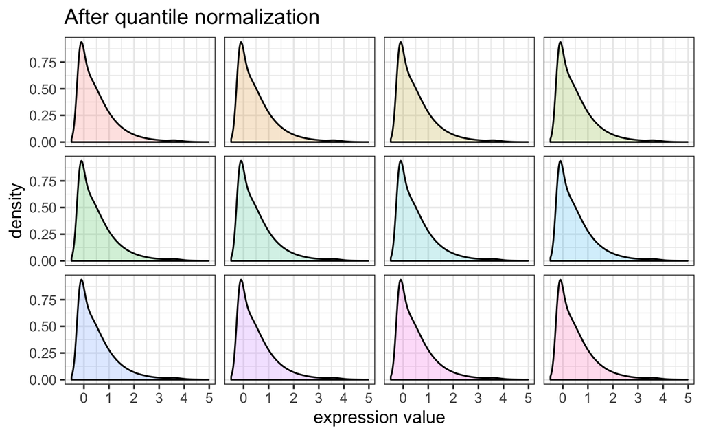

```r
qn_p +
  ggplot2::facet_wrap(~ Sample, ncol = 4) +
  ggplot2::theme(legend.position = "none",
                 strip.background = ggplot2::element_blank(),
                 strip.text = ggplot2::element_blank())
```

Quantile normalization was successful. The values for the RMA-normalized GSE39842 data are now more comparable to any data we would obtain through refine.bio.